# Exploring effective sample size environmental variables

Rose Andrew

15 June 2019

When testing association between variables, its significance can be inflated if the samples are non-independent. Spatial dependence in the form of spatial autocorrelation is very common in environmental variables. Some variables are more spatially autocorrelated than others, and as this will affect the rates of false positive associations, it has some bearing on the variables we choose for further analysis, at the very least. It may also be interesting to look at which variables pop out in analyses, in case some programs do a better job of accounting for it than others.

For bivariate analyses, this has already been implemented in the ‘modified.ttest’ functions in the ‘SpatialPack’ package (Dutilleul et al. 1993). There’s also a modified F-test for use with multiple predictors, but it gives identical ESS for bivariate associations (as we would hope).

Dutilleul, P., Clifford, P., Richardson, S., & Hemon, D. (1993). Modifying the t test for assessing the correlation between two spatial processes. Biometrics, 49(1), 305-314. doi:10.2307/2532625

For Bec Jordan’s 26 sampling locations, the ESS for pairwise associations between environmental variables range from 4 to 26.

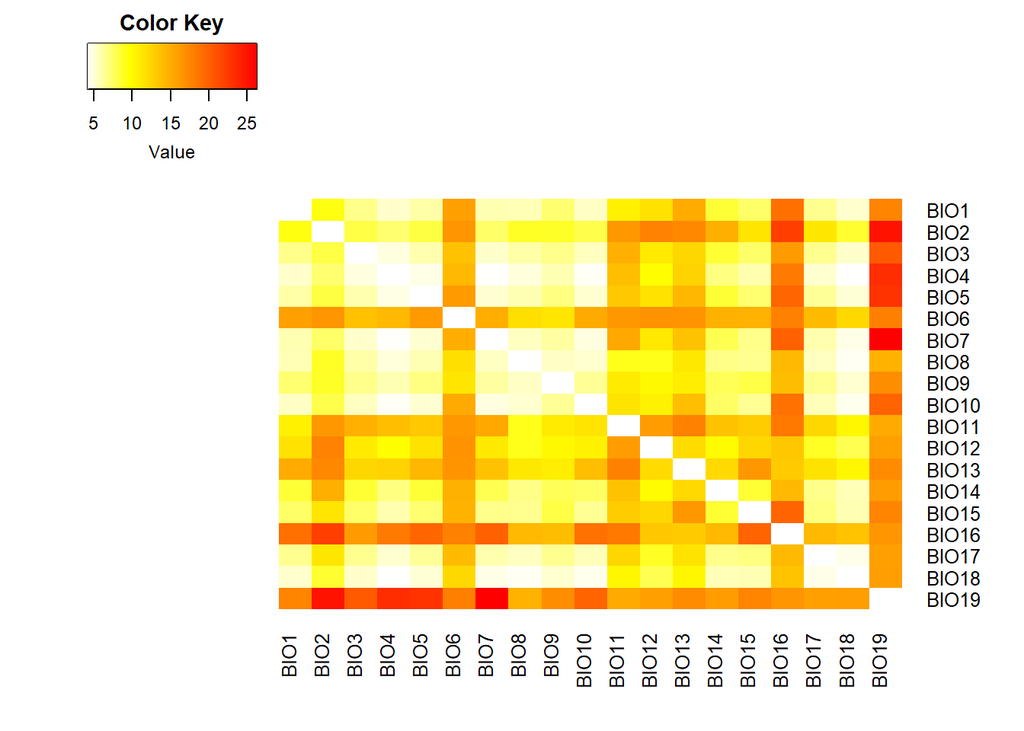

```r
## which columns to include in pairwise comparisons
envnames = envnames_all[which(!envnames_all %in% c("Lat", "Lon"))]

# extracting the coordinates from the radiata data set
coords <- as.data.frame(env[c("Lon", "Lat")])

## set up output data frame
mymatrix = matrix(nrow = length(envnames), ncol = length(envnames))
rownames(mymatrix) = envnames
colnames(mymatrix) = envnames
mymatrix2 = mymatrix

for (i in 1:length(envnames)) {
  # i=2
  xname = envnames[i]
  x = t(t(env[, xname]))
  for (j in c(1:length(envnames))[which(!envnames == xname)]) {
    yname = envnames[j]
    y = unlist(env[yname])

    # computing the modified F-test of spatial association
    z <- modified.Ftest(x, y, coords)
    mymatrix[i, j] = z$ESS

    # computing the modified t-test of spatial association
    z <- modified.ttest(x, y, coords)
    mymatrix2[i, j] = z$ESS

  }
}
# mymatrix
# mymatrix2
## ESS is the same for the F-test with two variables as for the t-test of a correlation

## Show in heatmap with legend
heatmap.2(mymatrix2, dendrogram = "none", scale = "none", trace = "none",
          density = "none", Rowv = F, Colv = F,
          col = rev(heat.colors(nrow(env) * nrow(env))))
```

This is a little frightening, but it might look worse because of spatial autocorrelation in both variables. In widespread Eucalyptus species, we might see lower global spatial autocorrelation. Also, they pertain to pairs of variables - a single number for each variable would be more useful.

Griffith (2005) developed several estimators of spatial effective sample size, including one for estimating the mean of one variable.

Griffith, D. A. (2005). Effective geographic sample size in the presence of spatial autocorrelation. Annals of the Association of American Geographers, 95(4), 740-760. doi:10.1111/j.1467-8306.2005.00484.x

Unfortunately, it hasn’t been implemented in an R package yet, so I’ve had a try myself. There are several ways to summarise global spatial autocorrelation, so I tried two: Moran’s I and APLE. For Moran’s I, inverse weighting of spatial distance was used, and gave fairly sensible results. APLE didn’t make much sense, so I used Moran’s I in the ESS formula.

```r
#########################################################################
## Autocorrelation - Moran's I in ape and APLE in spdep
#########################################################################

## Set up frame to hold output
envI = data.frame(env = envnames, MoransI = NA, pval = NA, APLE = NA)

## weights for ape
w = as.matrix(1 / dist(coords, upper = T))

## weights for spdep
listw0 = mat2listw(as.matrix(1 / dist(coords)))
listw1 = nb2listw(listw0$neighbours, listw0$weights, "W")

for (i in 1:length(envnames)) {
  varname = envnames[i]
  x = unlist(env[, varname])
  x = c(scale(unlist(env[, varname])))

  y = Moran.I(x, w)
  envI$MoransI[i] = y$observed
  envI$pval[i] = y$p.value
  envI$APLE[i] = aple(x, listw1)
}
```

Here’s the ESS calculation followed by the resulting table.

```r
#########################################################################
## Effective sample size for the mean (Griffith 2005)
#########################################################################

## n is the sample size
## rho is the spatial autocorrelation coefficient for a SAR model specification
##    - using Moran's I, as APLE gives negative values
ess = function(n, rho) {
  n_ess = n * (1 - (1 / (1 - exp(-1.92369)) * ((n - 1) / n) * (1 - exp(
  -2.12373 * rho + 0.20024 * sqrt(rho)
  ))))
  n_ess
}

## ESS for the mean for each variable, accounting for autocorrelation
envI$ESS = ess(26, envI$MoransI)

envI
```

```
##      env    MoransI         pval      APLE      ESS
## 1   BIO1 0.27178030 8.067963e-09 1.3615794 14.97033
## 2   BIO2 0.12310717 2.575016e-04 0.8770983 20.90524
## 3   BIO3 0.32545538 2.235101e-12 1.4690971 13.16560
## 4   BIO4 0.36919363 8.881784e-15 1.4459032 11.81894
## 5   BIO5 0.26748450 1.141654e-09 1.3016585 15.12231
## 6   BIO6 0.09395951 9.786417e-03 0.8072094 22.22203
## 7   BIO7 0.29576109 1.274780e-11 1.3315138 14.14267
## 8   BIO8 0.38415879 4.218847e-15 1.4669374 11.38247
## 9   BIO9 0.32551934 1.538392e-11 1.3813768 13.16356
## 10 BIO10 0.32512260 9.491297e-12 1.4108394 13.17627
## 11 BIO11 0.13096385 1.624149e-03 1.0612279 20.55765
## 12 BIO12 0.16099944 2.417252e-04 1.0023099 19.26174
## 13 BIO13 0.13804338 1.084001e-03 0.9492370 20.24741
## 14 BIO14 0.24401222 1.392151e-07 1.2045473 15.97302
## 15 BIO15 0.26701657 5.850409e-09 1.2933218 15.13894
## 16 BIO16 0.08206480 2.497462e-02 0.7013890 22.76953
## 17 BIO17 0.32200483 2.674239e-11 1.3005203 13.27648
## 18 BIO18 0.43309130 0.000000e+00 1.4119577 10.03731
## 19 BIO19 0.06752446 4.733582e-02 0.6581963 23.44358
```

BIO18 has a very low ESS, so let’s have a look at how it’s distributed in space.

[interactive chart not shown]

BIO19 has the highest ESS, so we may have more power to test associations with that variable.

[interactive chart not shown]

It looks like ESS is doing a good job of capturing the differences in spatial pattern. What’s not clear yet is whether software does a good or a poor job of accounting for spatial autocorrelation, and whether the ESS of the environmental variables affects power or false positives.